# Finding Clusters in Networks

## On real data, the answer changes

Li, Schaub & Peel · *arXiv* 2601.10502 (2026)

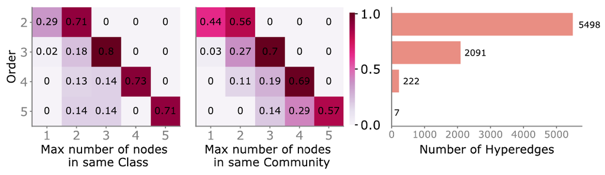

[figure not shown]

**Take-home 5:** Hypergraphs are bipartite graphs in disguise — but the trade-offs they reveal are genuine.

So we found communities

Now what can we actually do with them?

## Communities as a tool

**Causal identification in decision making**

Tamang et al. · (work in progress)

Peer effects and homophily are generically unidentifiable from observational network data alone.

If the network follows an SBM, detected communities proxy the latent homophilous attributes — adjusting for them yields consistent peer effect estimates.

**Network reconstruction**

Ferenczi, Young & Peel · *arXiv* 2601.10565 (2026)

Contact data is unsigned — we observe frequency, not sign.

Community structure provides the scaffold for jointly inferring assignments and relationship signs.

**Brain-muscle synergy decomposition**

Bittar et al. · (work in progress)

Muscle synergies are recovered via NMF — a special case of mixed-membership community detection.

The reformulation opens the door to identifiability analysis, uncertainty quantification, model selection, and detectability conditions for reliable recovery.

## When can we reliably know something about network structure?

**①** Are these the communities we are looking for?

**②** When is structure detectable at all?

**③** What if communities have communities?

**④** Does size matter?

**⑤** Does going higher-order actually change anything?

Thanks to my collaborators

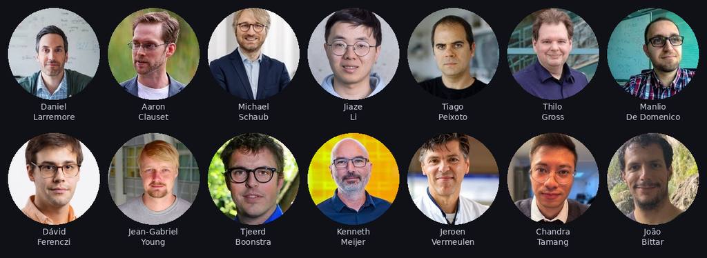

Finding structure is easy.

Knowing when it’s real is the whole problem.

Questions?

**Papers in this talk**

- Peel, Larremore & Clauset · *Science Advances* (2017) — metadata validation
- Schaub, Li & Peel · *arXiv* 2009.07196 — hierarchical community structure
- Peel & Schaub · *Physical Review E* (2024) — hierarchical detectability
- Li & Peel · *arXiv* 2604.18565 — minority community detection
- Li, Schaub & Peel · *arXiv* 2601.10502 — hypergraph community detection
- Peixoto, Peel & Gross · *arXiv* 2602.16937 — graphs and higher-order interactions
- Ferenczi, Young & Peel · *arXiv* 2601.10565 — signed network reconstruction
- Peel, Peixoto & De Domenico · *Nature Communications* (2022) — statistical inference in network science